# 05 – Does S. aureus phosphorylate histidine?

Bio253 HS2026 · STY vs STYH search, judged conservatively

**Claim to test:** Prust *et al.* 2021 (*Mol Cell Proteomics* 20:100034) report that ~8 % of all *S. aureus* phospho-sites are on **histidine** (pHis). Can we see pHis in our data – and how sure can we be?

The raw files were searched twice:

- **STY** – phosphorylation allowed on Ser, Thr, Tyr
- **STYH** – additionally on His

**ImportantBe sceptical – on purpose**

- pHis is **acid-labile**. Our workflow (Fe-IMAC enrichment, acidic LC) is not pHis-friendly, so many pHis may be lost – and the ones we “see” need extra scrutiny.
- The main source of false pHis is **mis-localisation**: if a peptide also contains S, T or Y, the search engine may put the phosphate on H although it sits on a neighbour – or the other way round.
- Allowing H as an extra acceptor makes the search space bigger, which by itself creates some extra (false) hits.

We therefore treat pHis **very conservatively**. You will build evidence tiers yourself.

```r
source("../R/setup.R")
# keep contaminants here: we want the complete peptide lists of both searches
styh <- read_sites("STYH", drop_contaminants = FALSE)
sty  <- read_sites("STY",  drop_contaminants = FALSE)
```

## 1. How many sites per residue in the two searches?

```r
bind_rows(styh, sty) |>
  distinct(search, site_id, residue) |>
  count(search, residue) |>
  pivot_wider(names_from = search, values_from = n, values_fill = 0)
```

| residue | STY | STYH |
| --- | --- | --- |
| S | 1818 | 1760 |
| T | 1462 | 1448 |
| Y | 658 | 646 |
| H | 0 | 424 |

**Question:** the STYH search finds more sites in total. Are the additional sites only His sites, or do S/T/Y counts also change? Why might they?

## 2. Localisation probability

`best_loc_prob` = best localisation probability of a site over all samples (1 = the search engine is sure the phosphate sits on exactly this residue).

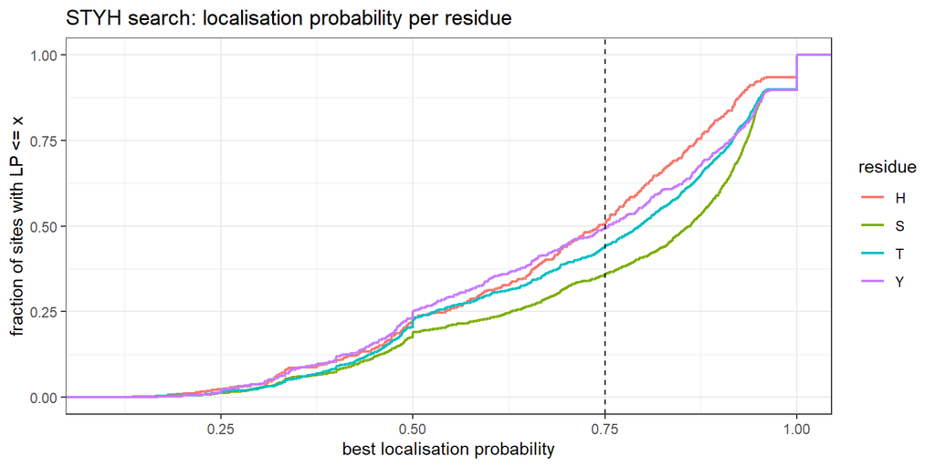

```r
site_level <- distinct(styh, site_id, residue, best_loc_prob)

ggplot(site_level, aes(best_loc_prob, colour = residue)) +
  stat_ecdf(linewidth = 0.8) +
  geom_vline(xintercept = 0.75, linetype = "dashed") +
  labs(x = "best localisation probability", y = "fraction of sites with LP <= x",
       title = "STYH search: localisation probability per residue")
```

```r
site_level |>
  mutate(lp_class = lp_class(best_loc_prob)) |>
  count(residue, lp_class) |>
  pivot_wider(names_from = lp_class, values_from = n, values_fill = 0)
```

| residue | <0.5 | 0.5-0.75 | 0.75-0.9 | 0.9-0.99 | >=0.99 |
| --- | --- | --- | --- | --- | --- |
| H | 93 | 122 | 131 | 50 | 28 |
| S | 311 | 320 | 431 | 519 | 179 |
| T | 299 | 338 | 392 | 272 | 147 |
| Y | 151 | 168 | 150 | 110 | 67 |

**Question:** Are His sites localised as well as S/T/Y sites? How many His sites have LP ≥ 0.75?

## 3. One evidence table for every His site

We now collect, for every His site, the evidence we need. Read each step.

### 3a. Sites, localisation and reproducibility

**Reproducibility is judged from the intensity** (detected = intensity > 0), not from the per-sample localisation probabilities: FragPipe sometimes reports an LP for a sample in which the site was *not quantified*.

```r
styh |>
  filter(residue == "H") |>
  summarise(sample_rows = n(),
            quantified = sum(!is.na(intensity)),
            LP_reported_but_not_quantified = sum(is.na(intensity) & loc_prob_fragpipe > 0,
                                                 na.rm = TRUE))
```

| sample_rows | quantified | LP_reported_but_not_quantified |
| --- | --- | --- |
| 11448 | 1358 | 31 |

```r
his <- styh |>
  filter(residue == "H") |>
  group_by(site_id, locus_tag, product, peptide, best_loc_prob) |>
  summarise(
    n_samples_quant = sum(!is.na(intensity)),                  # of 27
    n_samples_lp075 = sum(loc_prob_fragpipe >= 0.75, na.rm = TRUE),  # FragPipe LPs, for reference only
    max_reps_in_group = max(tapply(!is.na(intensity), group, sum)),  # best group, of 3
    .groups = "drop") |>
  mutate(lp_class = lp_class(best_loc_prob))
nrow(his)
```

```
[1] 424
```

### 3b. Is there an alternative acceptor on the peptide?

If the peptide contains **no S, T or Y at all**, the phosphate cannot be mis-placed onto a neighbouring S/T/Y. That is the strongest kind of evidence we can get from the search alone. A `Peptide` entry can contain several sequence variants separated by `;` – we take the variant with the fewest S/T/Y.

```r
peptide_variants("ANhEQIIEAIK;MANhEQIIEAIK")   # example: two variants, upper-cased
```

```
[[1]]
[1] "ANHEQIIEAIK"  "MANHEQIIEAIK"
```

```r
n_sty_acceptors("ANhEQIIEAIK;MANhEQIIEAIK")
```

```
[1] 0
```

```r
his <- his |>
  mutate(n_sty_acceptors = n_sty_acceptors(peptide),
         no_alt_acceptor = n_sty_acceptors == 0,
         co_phospho_STY  = co_phospho_sty(peptide))
count(his, no_alt_acceptor)
```

| no_alt_acceptor | n |
| --- | --- |
| FALSE | 405 |
| TRUE | 19 |

### 3c. Does the STY-only search explain the same peptide?

If the very same peptide was also identified as a phosphopeptide in the STY search, the spectrum can be explained **without** pHis. FragPipe writes phospho residues in lower case, so we compare upper-cased sequences. We count a His peptide as “explained” only if **all** its variants appear in the STY search.

```r
sty_peptides <- phosphopeptide_set(sty)
his <- his |>
  mutate(seen_in_STY_search   = all_variants_in(peptide, sty_peptides),
         partly_in_STY_search = any_variant_in(peptide, sty_peptides))
count(his, no_alt_acceptor, seen_in_STY_search)
```

| no_alt_acceptor | seen_in_STY_search | n |
| --- | --- | --- |
| FALSE | FALSE | 175 |
| FALSE | TRUE | 230 |
| TRUE | FALSE | 19 |

## 4. Worked example: HPr His15

HPr (phosphocarrier protein of the PTS sugar uptake system) carries a **textbook pHis at His15** – the phosphate is transferred from enzyme I to HPr-His15 and on to sugar transporters. If we find any real pHis, HPr should be a candidate.

```r
hpr <- find_protein("B7H15_05615") |> select(locus_tag, product, protein_key, staa8_uniprot)
hpr
```

| locus_tag | product | protein_key | staa8_uniprot |
| --- | --- | --- | --- |
| B7H15_05615 | phosphocarrier protein HPr | lcl_CP020619.1_prot_ARG45562.1_1096 | Q2FZH6 |

The same HPr peptide in the two searches:

```r
hpr_peptide <- "MEQNSYVIIDETGIHAR"
bind_rows(styh, sty) |>
  filter(protein_key %in% hpr$protein_key,
         str_detect(toupper(peptide), hpr_peptide)) |>
  group_by(search, site_id, residue, position, peptide, best_loc_prob) |>
  summarise(n_samples_quant = sum(!is.na(intensity)), .groups = "drop") |>
  arrange(search, position)
```

| search | site_id | residue | position | peptide | best_loc_prob | n_samples_quant |
| --- | --- | --- | --- | --- | --- | --- |
| STY | lcl_CP020619.1_prot_ARG45562.1_1096_S5 | S | 5 | EQNsyVIIDETGIHAR;MEQNsYVIIDETGIHAR | 0.9630 | 27 |
| STY | lcl_CP020619.1_prot_ARG45562.1_1096_Y6 | Y | 6 | EQNSyVIIDETGIHAR;EQNsyVIIDETGIHAR;MEQNSyVIIDETGIHAR;MEQNSyVIIDEtGIHAR | 0.9630 | 27 |
| STY | lcl_CP020619.1_prot_ARG45562.1_1096_T12 | T | 12 | EQNSYVIIDEtGIHAR;MEQNSYVIIDEtGIHAR;MEQNSYVIIDEtGIHARPATMLVQTASK;MEQNSyVIIDEtGIHAR | 0.9626 | 27 |
| STY | lcl_CP020619.1_prot_ARG45562.1_1096_T20 | T | 20 | MEQNSYVIIDETGIHARPAtMLVQTASK;PAtMLVQTASK | 0.9626 | 26 |
| STY | lcl_CP020619.1_prot_ARG45562.1_1096_T25 | T | 25 | MEQNSYVIIDETGIHARPATMLVQtASK;PATMLVQtASK;PATMLVQtASKFDSDIQLEYNGK | 0.9416 | 17 |
| STY | lcl_CP020619.1_prot_ARG45562.1_1096_S27 | S | 27 | MEQNSYVIIDETGIHARPATMLVQTAsK;PATMLVQTAsK;PATMLVQTAsKFDSDIQLEYNGK | 0.9037 | 12 |
| STYH | lcl_CP020619.1_prot_ARG45562.1_1096_S5 | S | 5 | EQNsyVIIDETGIHAR;MEQNsYVIIDETGIHAR | 0.9525 | 27 |
| STYH | lcl_CP020619.1_prot_ARG45562.1_1096_Y6 | Y | 6 | EQNSyVIIDETGIHAR;EQNsyVIIDETGIHAR;MEQNSyVIIDETGIHAR;MEQNSyVIIDEtGIHAR | 0.9525 | 27 |
| STYH | lcl_CP020619.1_prot_ARG45562.1_1096_T12 | T | 12 | EQNSYVIIDEtGIHAR;MEQNSYVIIDEtGIHAR;MEQNSYVIIDEtGIHARPATMLVQTASK;MEQNSyVIIDEtGIHAR | 0.9577 | 27 |
| STYH | lcl_CP020619.1_prot_ARG45562.1_1096_H15 | H | 15 | MEQNSYVIIDETGIhAR;MEQNSYVIIDETGIhARPATMLVQTASK | 0.8930 | 18 |
| STYH | lcl_CP020619.1_prot_ARG45562.1_1096_T20 | T | 20 | MEQNSYVIIDETGIHARPAtMLVQTASK;PAtMLVQTASK | 0.9594 | 26 |
| STYH | lcl_CP020619.1_prot_ARG45562.1_1096_T25 | T | 25 | MEQNSYVIIDETGIHARPATMLVQtASK;PATMLVQtASK;PATMLVQtASKFDSDIQLEYNGK | 0.9383 | 19 |
| STYH | lcl_CP020619.1_prot_ARG45562.1_1096_S27 | S | 27 | MEQNSYVIIDETGIHARPATMLVQTAsK;PATMLVQTAsK;PATMLVQTAsKFDSDIQLEYNGK;PATMLVQTAsKFDSDIQLEYNGKK | 0.9000 | 11 |

**Questions**

- In the STY search, where is the phosphate placed on this peptide? In STYH?
- Which interpretation is chemically / biologically more plausible, and why?
- Is the STY-search interpretation “wrong” – or simply the best it could do without H?
- Does this single example prove that pHis survives our workflow?

## 5. His sites on proteins that *should* carry pHis

Classical pHis proteins in bacteria: **histidine kinases** of two-component systems (autophosphorylation on His, transfer to Asp of the response regulator – note: pAsp was not searched), **HPr** and **enzyme I** of the PTS, and some metabolic enzymes (e.g. succinyl-CoA synthetase, nucleoside-diphosphate kinase).

```r
canonical_pattern <- "histidine kinase|phosphocarrier|PTS|phosphoenolpyruvate|response regulator|succinate--CoA|nucleoside-diphosphate kinase"
find_protein(canonical_pattern) |> count(product, sort = TRUE)
```

| product | n |
| --- | --- |
| DNA-binding response regulator | 16 |
| sensor histidine kinase | 6 |
| two-component sensor histidine kinase | 6 |
| PTS lactose transporter subunit IIB | 2 |
| histidine kinase | 2 |
| PTS alpha-glucoside transporter subunit IIBC | 1 |
| PTS ascorbate transporter subunit IIA | 1 |
| PTS ascorbate transporter subunit IIC | 1 |
| PTS fructose transporter subunit IIC | 1 |
| PTS galactitol transporter subunit IIB | 1 |
| PTS galactitol transporter subunit IIC | 1 |
| PTS glucose EIICBA component | 1 |
| PTS glucose transporter subunit IIABC | 1 |
| PTS glucose transporter subunit IIB | 1 |
| PTS glucose transporter subunit IIBC | 1 |
| PTS glucoside EIICBA component | 1 |
| PTS lactose EIICB component | 1 |
| PTS maltose transporter subunit IIBC | 1 |
| PTS mannitol transporter subunit IIA | 1 |
| PTS mannitol transporter subunit IICB | 1 |
| PTS mannose transporter subunit IIA | 1 |
| PTS mannose transporter subunit IIABC | 1 |
| PTS sugar transporter subunit IIA | 1 |
| PTS trehalose transporter subunit IIBC | 1 |
| PTS-dependent dihydroxyacetone kinase phosphotransferase subunit DhaM | 1 |
| cell wall metabolism sensor histidine kinase WalK | 1 |
| nucleoside-diphosphate kinase | 1 |
| phosphocarrier protein HPr | 1 |
| phosphoenolpyruvate carboxykinase (ATP) | 1 |
| phosphoenolpyruvate synthetase regulatory protein | 1 |
| phosphoenolpyruvate–protein phosphotransferase | 1 |

```r
his |>
  filter(str_detect(product, regex(canonical_pattern, ignore_case = TRUE))) |>
  select(locus_tag, product, site_id, peptide, best_loc_prob, n_sty_acceptors,
         seen_in_STY_search, max_reps_in_group)
```

| locus_tag | product | site_id | peptide | best_loc_prob | n_sty_acceptors | seen_in_STY_search | max_reps_in_group |
| --- | --- | --- | --- | --- | --- | --- | --- |
| B7H15_01055 | PTS glucose EIICBA component | lcl_CP020619.1_prot_ARG44726.1_209_H533 | SATSELShIVHAPLTGEVTPLSEVPDQVFSEK | 0.8262 | 8 | TRUE | 1 |
| B7H15_01055 | PTS glucose EIICBA component | lcl_CP020619.1_prot_ARG44726.1_209_H536 | SATSELSHIVhAPLTGEVTPLSEVPDQVFSEK | 0.9187 | 8 | TRUE | 3 |
| B7H15_03905 | PTS fructose transporter subunit IIC | lcl_CP020619.1_prot_ARG45242.1_758_H135 | LLhASSPEEVLAIIDEADDEVTKEEEAEAEAQQVATAEQSSK | 0.6995 | 6 | TRUE | 1 |
| B7H15_03905 | PTS fructose transporter subunit IIC | lcl_CP020619.1_prot_ARG45242.1_758_H225 | VETNGSSGIKNhLTEQDIENATGIIVAADVHVETDRFDGK | 0.7499 | 6 | TRUE | 1 |
| B7H15_03905 | PTS fructose transporter subunit IIC | lcl_CP020619.1_prot_ARG45242.1_758_H49 | EAIhNRESQSTTGIGEGIAIPHAK | 0.8570 | 4 | TRUE | 2 |
| B7H15_03935 | DNA-binding response regulator | lcl_CP020619.1_prot_ARG45248.1_764_H124 | YHhQPVEQLSFDELTLINLSK | 0.3258 | 4 | TRUE | 1 |
| B7H15_05615 | phosphocarrier protein HPr | lcl_CP020619.1_prot_ARG45562.1_1096_H15 | MEQNSYVIIDETGIhAR;MEQNSYVIIDETGIhARPATMLVQTASK | 0.8930 | 3 | TRUE | 3 |
| B7H15_09405 | PTS glucose transporter subunit IIBC | lcl_CP020619.1_prot_ARG46284.1_1851_H266 | YQAGFFPIMMFGIPAAALAMYhtAKTTQKK | 0.5571 | 5 | TRUE | 1 |
| B7H15_09750 | phosphoenolpyruvate carboxykinase (ATP) | lcl_CP020619.1_prot_ARG46349.1_1920_H328 | AAYPINhIDNIVVPSK | 0.4915 | 2 | TRUE | 1 |
| B7H15_11300 | DNA-binding response regulator | lcl_CP020619.1_prot_ARG46599.1_2192_H128 | IIDCLETAhTR | 0.7882 | 2 | FALSE | 1 |
| B7H15_11960 | PTS lactose transporter subunit IIB | lcl_CP020619.1_prot_ARG46720.1_2319_H398 | LALNDCWPDLIFPEsEIAFIVLhFGGSIK | 0.8887 | 2 | FALSE | 1 |
| B7H15_11965 | PTS mannitol transporter subunit IIA | lcl_CP020619.1_prot_ARG46721.1_2320_H74 | TNVIhSGLTLLQIPEGVDWDGEVVK | 0.6947 | 3 | TRUE | 3 |
| B7H15_14115 | PTS glucoside EIICBA component | lcl_CP020619.1_prot_ARG47110.1_2741_H135 | ELSQAAKEPAhALVLGIPTLQTGVFGGIIMGALAAWCYNK | 0.7380 | 4 | TRUE | 1 |
| B7H15_14710 | PTS mannose transporter subunit IIABC | lcl_CP020619.1_prot_ARG47222.1_2860_H111 | IINQDAPIYQSETNYhSKDR | 0.3253 | 5 | TRUE | 1 |
| B7H15_14710 | PTS mannose transporter subunit IIABC | lcl_CP020619.1_prot_ARG47222.1_2860_H474 | NTPVIAVDAPAQhTQLHDTDITQHDTEVDNVDNTAK | 0.7000 | 6 | TRUE | 1 |
| B7H15_14710 | PTS mannose transporter subunit IIABC | lcl_CP020619.1_prot_ARG47222.1_2860_H500 | HShLNKPSHVFDQQTMIITDHDMSR | 0.5232 | 5 | TRUE | 1 |

**Question:** Do any histidine kinases show a His site? Is the site at the conserved, autophosphorylated His (look at the protein in UniProt via `staa8_uniprot`)? What about the many His sites on proteins that are *not* known pHis proteins?

## 6. Your task: build confidence tiers

Combine the evidence into **tiers**, from “strongest candidate” to “unreliable”. Suggested criteria (you decide the order and thresholds – and justify them!):

| evidence | column |
| --- | --- |
| no alternative S/T/Y acceptor on the peptide | `no_alt_acceptor` |
| well localised | `best_loc_prob >= 0.75` |
| reproducible: ≥ 2 of 3 replicates in some group | `max_reps_in_group >= 2` |
| peptide **not** explained by the STY search | `!seen_in_STY_search` |

Write your tiers below (set `eval: true` once you filled in the conditions). Number tiers 1 (strongest) to 6 (weakest) and **start every label with the number**.

```r
my_tiers <- his |>
  mutate(
    tier = case_when(
      no_alt_acceptor &
        best_loc_prob >= 0.75 &
        max_reps_in_group >= 2 &
        !seen_in_STY_search ~ "1 strongest",
      best_loc_prob >= 0.75 &
        max_reps_in_group >= 2 &
        !seen_in_STY_search ~ "2 very strong",
      no_alt_acceptor &
        best_loc_prob >= 0.75 ~ "3 strong",
      best_loc_prob >= 0.75 ~ "4 moderate",
      no_alt_acceptor ~ "5 weak",
      TRUE ~ "6 unreliable"))
count(my_tiers, tier)
```

| tier | n |
| --- | --- |
| 1 strongest | 5 |
| 2 very strong | 28 |
| 3 strong | 13 |
| 4 moderate | 163 |
| 5 weak | 1 |
| 6 unreliable | 214 |

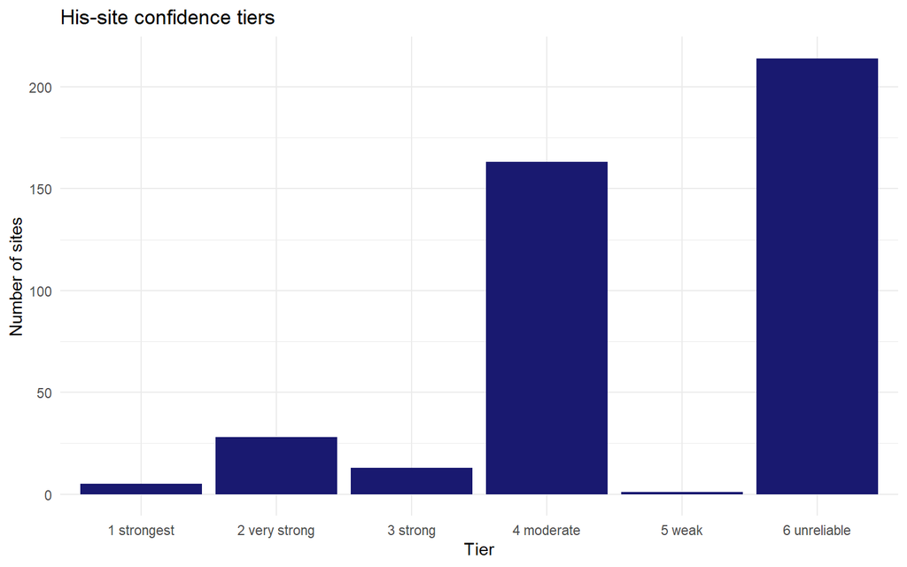

```r
#add plot

my_tiers |>
  count(tier) |>
  mutate(tier = factor(
    tier,
    levels = c(
      "1 strongest",
      "2 very strong",
      "3 strong",
      "4 moderate",
      "5 weak",
      "6 unreliable"
    )
  )) |>
  ggplot(aes(tier, n)) +
  geom_col() +
   geom_col(fill = "midnightblue") +
  labs(
    x = "Tier",
    y = "Number of sites",
    title = "His-site confidence tiers"
  ) +
  theme_minimal()
```

Check your tiers against the lecturer’s reference (counts only – it tells you *how many* sites agree, not *which*):

```r
check_his_tiers(my_tiers)
```

```
       reference_tier
my_tier   1   2   3   4   5   6
      1   5   0   0   0   0   0
      2   0   0   0  28   0   0
      3   0  13   0   0   0   0
      4   0   0   0  75  88   0
      5   0   0   1   0   0   0
      6   0   0   0   0   0 214
```

Which are the strongest sites? The following sites fullfil all criteria of the strongest confidence tier: no alternative S/T/Y acceptor, localisation probability ≥ 0.75, reproducible detection (≥ 2 replicates in one group), and not explained by the STY search (are located in tier 1).

```r
my_tiers |>
  filter(tier == "1 strongest") |>
  select(
    site_id,
    locus_tag,
    product,
    peptide,
    best_loc_prob,
    max_reps_in_group)
```

| site_id | locus_tag | product | peptide | best_loc_prob | max_reps_in_group |
| --- | --- | --- | --- | --- | --- |
| lcl_CP020619.1_prot_ARG45065.1_568_H4 | B7H15_02955 | 50S ribosomal protein L7/L12 | ANhEQIIEAIK;MANhEQIIEAIK | 1.0000 | 3 |
| lcl_CP020619.1_prot_ARG45665.1_1202_H70 | B7H15_06150 | ribosomal RNA small subunit methyltransferase H | EVLKDHLhK | 0.7672 | 2 |
| lcl_CP020619.1_prot_ARG45823.1_1368_H111 | B7H15_06980 | homoserine dehydrogenase | DLLAVhLK | 1.0000 | 2 |
| lcl_CP020619.1_prot_ARG46060.1_1618_H18 | B7H15_08235 | segregation and condensation protein A | LDAFNGPLDLLLhLIQK | 1.0000 | 2 |
| lcl_CP020619.1_prot_ARG46318.1_1886_H1785 | B7H15_09580 | peptidase | HLVEQALNQAIDQINhADK | 0.7662 | 2 |

according to String, they are not linked in any way. They don’t belong to an obvious pathway.

## 6.1 is it random (histidine kinase annotated proteins)?

Possible histidine kinase annotated proteins (genome wide)

```r
find_protein("histidine kinase") |>
  select(locus_tag, product)
```

| locus_tag | product |
| --- | --- |
| B7H15_00115 | cell wall metabolism sensor histidine kinase WalK |
| B7H15_01195 | sensor histidine kinase |
| B7H15_01400 | sensor histidine kinase |
| B7H15_03695 | sensor histidine kinase |
| B7H15_03930 | two-component sensor histidine kinase |
| B7H15_06945 | two-component sensor histidine kinase |
| B7H15_07455 | two-component sensor histidine kinase |
| B7H15_08215 | two-component sensor histidine kinase |
| B7H15_09215 | sensor histidine kinase |
| B7H15_10150 | histidine kinase |
| B7H15_10500 | two-component sensor histidine kinase |
| B7H15_11550 | sensor histidine kinase |
| B7H15_13105 | two-component sensor histidine kinase |
| B7H15_13260 | sensor histidine kinase |
| B7H15_14615 | histidine kinase |

found in the dataset styh sites

```r
tcs <- find_protein("histidine kinase") |>
  select(locus_tag, product)

styh |>
  distinct(locus_tag) |>
  inner_join(tcs, by = "locus_tag")
```

| locus_tag | product |
| --- | --- |
| B7H15_00115 | cell wall metabolism sensor histidine kinase WalK |
| B7H15_03930 | two-component sensor histidine kinase |
| B7H15_07455 | two-component sensor histidine kinase |
| B7H15_11550 | sensor histidine kinase |
| B7H15_13105 | two-component sensor histidine kinase |
| B7H15_14615 | histidine kinase |

Following a test is the phosphorilisation is random or not on histidine kinase annotated proteins(Fisher Test).

```r
##  define TCS-proteines
tcs <- find_protein("histidine kinase") |>
  select(locus_tag) |>
  distinct()

## All proteins
all_proteins <- styh |>
  select(locus_tag) |>
  distinct() |>
  mutate(
    TCS = locus_tag %in% tcs$locus_tag
  )

## Proteines with at least one pHis
his_proteins <- his |>
  select(locus_tag) |>
  distinct() |>
  mutate(has_pHis = TRUE)

## put together
protein_tbl <- all_proteins |>
  left_join(his_proteins, by = "locus_tag") |>
  mutate(
    has_pHis = ifelse(is.na(has_pHis), FALSE, has_pHis)
  )

## 2x2-table
tab <- table(
  protein_tbl$TCS,
  protein_tbl$has_pHis
)

tab
```

```
        FALSE TRUE
  FALSE   793  312
  TRUE      6    0
```

```r
## Fisher Exact Test
fisher.test(tab)
```

```
    Fisher's Exact Test for Count Data

data:  tab
p-value = 0.1934
alternative hypothesis: true odds ratio is not equal to 1
95 percent confidence interval:
 0.000000 2.172521
sample estimates:
odds ratio
         0
```

Six proteins annotated as histidine kinases (TCS proteins) were identified in the dataset. None contained a detected histidine phosphosite. Consequently, the estimated odds ratio was 0. However, Fisher’s exact test did not indicate a significant association between TCS membership and the occurrence of histidine phosphosites (p = 0.193). Not really valuable because only very few histidine kinase annotated proteins detected.

## 7. Real or artefact? A decision framework

For each candidate, go through this list and write your verdict in your lab notebook.

1. **Chemistry:** acid-labile pHis + acidic workflow → is it plausible the site survived?
2. **Localisation:** LP ≥ 0.75? Any S/T/Y on the peptide? Same peptide explained by STY?
3. **Reproducibility:** seen in ≥ 2/3 replicates of a group? In more than one group?
4. **Biology:** is the protein a known His-phosphorylated protein? Is the His conserved?
5. **Spectra:** (beyond this course, but name it) inspect the MS2 spectra – are there fragment ions that pin the phosphate to H? pHis shows characteristic neutral losses (e.g. −80, −98, −116 Da).
6. **Orthogonal validation:** pHis-specific antibodies, non-acidic enrichment, mutation of the His.

**Discussion:** after this analysis, how would you phrase our evidence for (or against) the claim of Prust *et al.*? Distinguish “we found no evidence” from “we found evidence of absence”.